# Déterminants de la mortalité infanto-Juvénile au Cameroun

Dimitry Yonta

2024-12-15

Selon les données de la dernière enquête démographique et de santé du Cameroun (EDS 2018), 80 enfants sur 1000 naissances vivantes sont décédés avant leurs cinquième anniversaire au cours des 5 dernières années précédant la collecte des données. La mortalité infanto-juvénile constitue un véritable problème de santé publique car elle entraine des impacts sur le développement social et économique d’un pays.

Plusieurs études menées dans certaines régions du Cameroun ont exploré les facteurs cliniques associés non pas à la mortalité infanto juvénile mais à la mortalité néonatale. Les facteurs socio démographiques, pourtant cruciaux, n’ont pas suffisamment été exploré. Notons également que les méthodes utilisées dans ces études ne prennent pas en compte la possibilité qu’un enfant décède après la période d’observation ce qui cause potentiellement des biais. Or les approches par analyse de survie permettent de mieux prendre en compte cette particularité.

Ainsi donc, j’ai exploré les facteurs sociodémographiques associés à la mortalité infanto juvénile en utilisant le modèle à risque proportionnel de COX. Les facteurs sociodémographiques suspectés et ceux relevés dans d’autres contexte inclus: l’âge de la mère à la première naissance, le niveau d’éducation de la mère, le sexe de l’enfant, le poids de l’enfant à la naissance, la religion, l’index de richesse, le nombre d’enfant dans le ménage, le rang de l’enfant, l’intervalle avec la naissance précédente; et le fait d’être jumeaux et le lieu de résidence.

## 1 Importation des donnees, selection et creaction des variables

```r
## Importation des packages
pacman::p_load(haven, tidyverse, gtsummary, survey, labelled,survival, survminer)

## Importation des bases de donnees
menage <- read_dta("C:/Users/DELL/OneDrive/Desktop/Mes Projets_R/epidemioR/DHS STATA/CMHR71DT/CMHR71FL.DTA")

femmes <- read_dta("C:/Users/DELL/OneDrive/Desktop/Mes Projets_R/epidemioR/DHS STATA/CMIR71DT/CMIR71FL.DTA")

enfant <- read_dta("C:/Users/DELL/OneDrive/Desktop/Mes Projets_R/epidemioR/DHS STATA/CMKR71DT/CMKR71FL.DTA")

## Prise en compte des etiquettes

femmes <- femmes %>%
  unlabelled()

enfant <- enfant %>%
  unlabelled()

menage <- menage %>%
  unlabelled()
```

```r
# Selection des variables et recodage

## Creation de la variable date_interview

femmes <- femmes%>%
  mutate( date_interview = dmy(str_c(v016, v006, v007, sep = "/")))

## joindre chaque femme a son enfants dans la base enfants

enfant <- enfant %>%
  left_join( femmes %>%
               select(caseid,date_interview), by = "caseid")

## calculons l'intervalle d'observation le temps entre la naissance de l'enfant et l'interview en mois

enfant <-  enfant %>%
  mutate(date_naissance_enfant =dmy(str_c(b17, b1, b2, sep = "/")),
         intervalle_observation = interval( date_naissance_enfant,date_interview) %>% time_length(unit = "month"))
```

```r
## Selection des variables

base <- enfant %>%
  select(caseid,v012, v024, v025,v190, v106,v130,m18, m19,intervalle_observation,b4,b5,b7,b8,b11,b12,b0,bidx,bord)

## calculons l'age de la mere a la naissance

base <- base %>%
  mutate( age_mere_naissance = ifelse(b5=="yes", v012-b8, (v012*12 -b7)/12),
          age_mere_naissance = case_when(
            age_mere_naissance < 20 ~ "< 20",
            age_mere_naissance >=20 & age_mere_naissance < 30 ~ "20-29",
            age_mere_naissance >=29 & age_mere_naissance < 40 ~ "30-39",
            age_mere_naissance >=40 & age_mere_naissance < 50 ~ "40-49"
          ))

## Rang de l'enfant dans la flatrie

base <- base %>%
  mutate(rang_naissance = case_when(
    bord == 1 ~ "1",
    bord == 2|bord ==3 ~ "2-3",
    bord > 3 & bord<=6 ~ "4-6",
    bord > 6 ~ "+7"
  ))

## Poids a la naissance
base <- base %>%
  mutate( poids_naissance = case_when(
    m19 < 2500 ~ "inferieur a 2,5 kg",
    m19 >=2500 & m19 <= 3500 ~ "2,5-3,5 kg",
    m19 >3500 & m19 <= 6000 ~ "superieur a 3,5 kg",
    m19 > 6000 ~ "Je ne sais pas/ pas été pésé"
  ))

## Intervalle avec la naissance precedente

base <- base %>%
  mutate(intervalle_naissance_prec = case_when(
    b11 < 24 ~ "inferieur a 2 ans",
    b11 == 24 ~ " 2 ans",
    b11 > 24 ~ "plus de 2 ans",
     is.na(b11) ~ "Premier enfant"
  ))



## Creaction des variables de survie

base <- base %>%
  mutate( deces = ifelse( b5 == "yes", 0, 1),
          temps = ifelse( b5 == "yes", intervalle_observation, b7))


## Recodage de base$v024 en base$v024_rec
base$v024<- base$v024 %>%
  fct_recode(
    "Adamawa" = "adamawa",
    "Centre" = "centre (without yaounde)",
    "Littoral" = "douala",
    "Est" = "east",
    "Extreme Nord" = "far-north",
    "Littoral" = "littoral (without douala)",
    "Nord" = "north",
    "Nord Ouest" = "north-west",
    "ouest" = "west",
    "Sud" = "south",
    "Sud ouest" = "south-west",
    "Centre" = "yaounde"
  )

## Recodage de base$v025 en base$v025_rec
base$v025 <- base$v025 %>%
  fct_recode(
    "Urbain" = "urban",
    "Rural" = "rural"
  )

## Recodage de base$v190 en base$v190_rec
base$v190 <- base$v190 %>%
  fct_recode(
    "Pauvre" = "poorest",
    "Pauvre" = "poorer",
    "Moyen" = "middle",
    "Riche" = "richer",
    "Riche" = "richest"
  )
## Recodage de base$v106 en base$v106_rec
base$v106 <- base$v106 %>%
  fct_recode(
    "Pas d'education" = "no education",
    "Primaire" = "primary",
    "Secondaire" = "secondary",
    "Superieur" = "higher"
  )

## Recodage de base$v130 en base$v130_rec
base$v130 <- base$v130 %>%
  fct_recode(
    "Chretien" = "catholic",
    "Chretien" = "protestant",
    "Chretien" = "other christians",
    "Musulman" = "muslim",
    "Animiste" = "animist",
    "Aucune" = "none",
    "Aucune" = "other"
  )

## Recodage de base$b4 en base$b4_rec
base$b4<- base$b4 %>%
  fct_recode(
    "Masculin" = "male",
    "Feminin" = "female"
  )

## Recodage de base$b5 en base$b5_rec
base$b5 <- base$b5 %>%
  fct_recode(
    "Non" = "no",
    "Oui" = "yes"
  )

## Recodage de base$b0 en base$b0_rec
base$b0 <- base$b0 %>%
  fct_recode(
    "Naissance unique" = "single birth",
    "1er d'une naissance multiple" = "1st of multiple",
    "2 eme d'une naissance multiple" = "2nd of multiple",
    "2 eme d'une naissance multiple" = "3rd of multiple",
    "4e d'une naissance multiple" = "4th of multiple",
    "5e d'une naissance multiple" = "5th of multiple"
  ) %>%
  fct_drop()
```

```r
# Definition des modalites de reference

## Réordonnancement de base$v024
base$v024 <- base$v024 %>%
  fct_relevel(
    "Centre", "Adamawa", "Littoral", "Est", "Extreme Nord", "Nord",
    "Nord Ouest", "ouest", "Sud", "Sud ouest"
  )
## Réordonnancement de base$v025
base$v025 <- base$v025 %>%
  fct_relevel(
    "Rural", "Urbain"
  )

## Réordonnancement de base$v190
base$v190 <- base$v190 %>%
  fct_relevel(
    "Riche", "Pauvre", "Moyen")

## Réordonnancement de base$v130
base$v130 <- base$v130 %>%
  fct_relevel(
    "Chretien", "Musulman", "Animiste", "Aucune"
  )
## Réordonnancement de base$b4
base$b4 <- base$b4 %>%
  fct_relevel(
    "Feminin", "Masculin"
  )

## Réordonnancement de base$age_mere_naissance
base$age_mere_naissance <- base$age_mere_naissance %>%
  fct_relevel(
    "20-29", "< 20", "30-39", "40-49"
  )
## Réordonnancement de base$rang_naissance
base$rang_naissance <- base$rang_naissance %>%
  fct_relevel(
    "1", "2-3", "4-6", "+7"
  )
## Réordonnancement de base$poids_naissance
base$poids_naissance <- base$poids_naissance %>%
  fct_relevel(
    "inferieur a 2,5 kg","2,5-3,5 kg", "superieur a 3,5 kg", "Je ne sais pas/ pas été pésé"
  )
## Réordonnancement de base$intervalle_naissance_prec
base$intervalle_naissance_prec <- base$intervalle_naissance_prec %>%
  fct_relevel(
    " 2 ans", "inferieur a 2 ans", "Premier enfant", "plus de 2 ans"
  )
```

```r
# Definition des etiquettes des variables

base <- base %>%
  set_variable_labels( b0 = "L'enfant est jumeau?", b4 = "Sexe", v024 = "Region",
                       v025 = "Lieu de residence", v190 = "Index de richesse",v106 = "Niveau d'education de la mère", v130 = "Religion", intervalle_observation = "Intervalle d'observation de chaque enfant", deces = "l'enfant est decede",age_mere_naissance = "age de la mere a la naissance de l'enfant", rang_naissance = "Rang de l'enfant dans la flatrie", poids_naissance = "Poids de l'enfant a la naissance", temps = "temps de suivie",intervalle_naissance_prec = "Intervalle de temps par rapport a la naissance precedente")
```

## 2 Debut des analyses

```r
## Visualisation global de la base

summary(base)
```

```
##     caseid               v012                 v024          v025
##  Length:9733        Min.   :15.00   Centre      :1841   Rural :5415
##  Class :character   1st Qu.:23.00   Extreme Nord:1299   Urbain:4318
##  Mode  :character   Median :28.00   Nord        :1217
##                     Mean   :28.23   Littoral    :1119
##                     3rd Qu.:33.00   Est         :1003
##                     Max.   :49.00   ouest       : 952
##                                     (Other)     :2302
##      v190                   v106            v130
##  Riche :3308   Pas d'education:2246   Chretien:6851
##  Pauvre:4094   Primaire       :3240   Musulman:2539
##  Moyen :2331   Secondaire     :3747   Animiste: 142
##                Superieur      : 500   Aucune  : 201
##
##
##
##                    m18            m19       intervalle_observation
##  very large          :1061   Min.   : 500   Min.   : 0.00
##  larger than average :1906   1st Qu.:3200   1st Qu.:14.13
##  average             :5159   Median :3900   Median :29.19
##  smaller than average: 908   Mean   :5640   Mean   :29.35
##  very small          : 463   3rd Qu.:9996   3rd Qu.:44.20
##  don't know          : 236   Max.   :9998   Max.   :60.00
##
##         b4         b5             b7               b8             b11
##  Feminin :4795   Non: 648   Min.   : 0.000   Min.   :0.000   Min.   :  8.00
##  Masculin:4938   Oui:9085   1st Qu.: 0.000   1st Qu.:1.000   1st Qu.: 24.00
##                             Median : 1.000   Median :2.000   Median : 31.00
##                             Mean   : 7.162   Mean   :1.958   Mean   : 37.32
##                             3rd Qu.:12.000   3rd Qu.:3.000   3rd Qu.: 44.00
##                             Max.   :48.000   Max.   :4.000   Max.   :276.00
##                             NA's   :9085     NA's   :648     NA's   :2320
##       b12                                     b0            bidx
##  Min.   : 8.00   Naissance unique              :9328   Min.   :1.000
##  1st Qu.:21.00   1er d'une naissance multiple  : 201   1st Qu.:1.000
##  Median :26.00   2 eme d'une naissance multiple: 204   Median :1.000
##  Mean   :26.83                                         Mean   :1.395
##  3rd Qu.:32.50                                         3rd Qu.:2.000
##  Max.   :59.00                                         Max.   :5.000
##  NA's   :6626
```

[output cut: 9 more lines]

```
##  inferieur a 2,5 kg          : 465    2 ans           : 284
##  2,5-3,5 kg                  :3647   inferieur a 2 ans:1850
##  superieur a 3,5 kg          :2336   Premier enfant   :2320
##  Je ne sais pas/ pas été pésé:3285   plus de 2 ans    :5279
##
##
##
##      deces             temps
##  Min.   :0.00000   Min.   : 0.00
##  1st Qu.:0.00000   1st Qu.:12.00
##  Median :0.00000   Median :26.90
##  Mean   :0.06658   Mean   :27.65
##  3rd Qu.:0.00000   3rd Qu.:42.97
##  Max.   :1.00000   Max.   :60.00
##
```

```r
## Frequence de deces
library(questionr)

freq(base$deces)
```

|  | n | % | val% |
| --- | --- | --- | --- |
| 0 | 9085 | 93.3 | 93.3 |
| 1 | 648 | 6.7 | 6.7 |

```r
##Description des variables

base %>%
  tbl_summary( include =  c(v024,v025,v190,v106,v130, b4,b5,b0,age_mere_naissance,rang_naissance,poids_naissance,intervalle_naissance_prec)) %>%
  italicize_labels() %>%
  bold_labels()
```

| **Characteristic** | **N = 9,733**<sup>1</sup> |
| --- | --- |
| Region |  |
| Centre | 1,841 (19%) |
| Adamawa | 734 (7.5%) |
| Littoral | 1,119 (11%) |
| Est | 1,003 (10%) |
| Extreme Nord | 1,299 (13%) |
| Nord | 1,217 (13%) |
| Nord Ouest | 473 (4.9%) |
| ouest | 952 (9.8%) |
| Sud | 928 (9.5%) |
| Sud ouest | 167 (1.7%) |
| Lieu de residence |  |
| Rural | 5,415 (56%) |
| Urbain | 4,318 (44%) |
| Index de richesse |  |
| Riche | 3,308 (34%) |
| Pauvre | 4,094 (42%) |
| Moyen | 2,331 (24%) |
| Niveau d'education de la mère |  |
| Pas d'education | 2,246 (23%) |
| Primaire | 3,240 (33%) |
| Secondaire | 3,747 (38%) |
| Superieur | 500 (5.1%) |
| Religion |  |
| Chretien | 6,851 (70%) |
| Musulman | 2,539 (26%) |
| Animiste | 142 (1.5%) |
| Aucune | 201 (2.1%) |
| Sexe |  |
| Feminin | 4,795 (49%) |
| Masculin | 4,938 (51%) |
| child is alive |  |
| Non | 648 (6.7%) |
| Oui | 9,085 (93%) |
| L'enfant est jumeau? |  |
| Naissance unique | 9,328 (96%) |
| 1er d'une naissance multiple | 201 (2.1%) |
| 2 eme d'une naissance multiple | 204 (2.1%) |
| age de la mere a la naissance de l'enfant |  |
| 20-29 | 5,189 (53%) |
| < 20 | 1,575 (16%) |
| 30-39 | 2,656 (27%) |
| 40-49 | 313 (3.2%) |
| Rang de l'enfant dans la flatrie |  |
| 1 | 2,283 (23%) |
| 2-3 | 3,497 (36%) |
| 4-6 | 2,871 (29%) |
| +7 | 1,082 (11%) |
| Poids de l'enfant a la naissance |  |
| inferieur a 2,5 kg | 465 (4.8%) |
| 2,5-3,5 kg | 3,647 (37%) |
| superieur a 3,5 kg | 2,336 (24%) |
| Je ne sais pas/ pas été pésé | 3,285 (34%) |
| Intervalle de temps par rapport a la naissance precedente |  |
| 2 ans | 284 (2.9%) |
| inferieur a 2 ans | 1,850 (19%) |
| Premier enfant | 2,320 (24%) |
| plus de 2 ans | 5,279 (54%) |

<sup>1</sup> n (%)

## 3 courbe de Survie globale

```r
courbe <- survfit( Surv(temps,deces)~ 1, data = base)

courbe
```

```
## Call: survfit(formula = Surv(temps, deces) ~ 1, data = base)
##
##         n events median 0.95LCL 0.95UCL
## [1,] 9733    648     NA      NA      NA
```

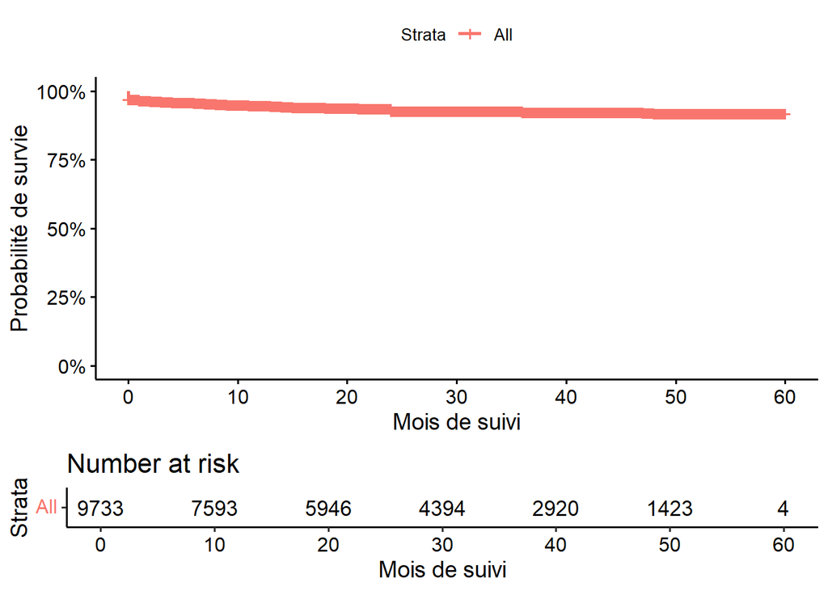

```r
## courbe de kaplan meier

ggsurvplot(courbe,
    conf.int = FALSE, # ne pas montrer l'intervalle de confiance des estimations KM
    surv.scale = "percent", # présente les probabilités sur l'axe des ordonnées en %.
    break.time.by = 10, # présente l'axe du temps avec un incrément de 10 mois
    xlab = "Mois de suivi",
    ylab = "Probabilité de survie",risk.table = T)
```

## 4 Comparaison des courbes de selon les caracteristiques

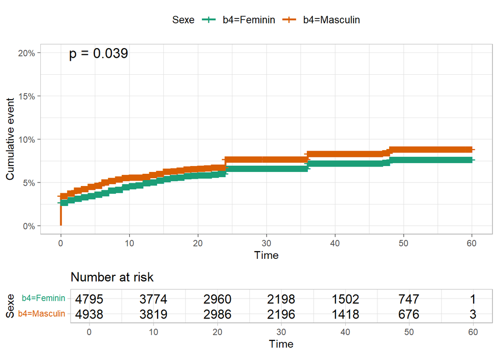

```r
courbe_sexe <- survfit( Surv(temps,deces)~b4, data = base)

ggsurvplot(courbe_sexe, fun = "event", risk.table = TRUE,surv.scale = "percent", break.time.by = 10, pval = TRUE,
           conf.int = FALSE,
           font.legend = 10,
           legend.title = "Sexe",
    palette = "Dark2", # spécifier la palette de couleurs
    ggtheme = theme_light() # simplifie le fond du graphique
)
```

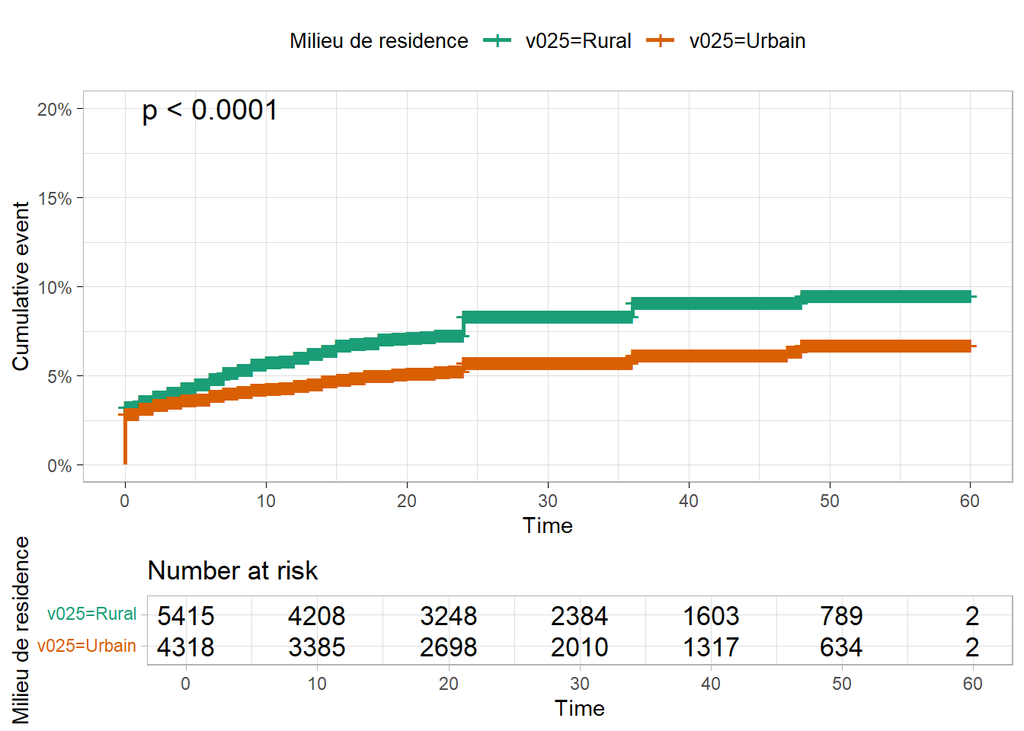

```r
courbe_residence <- survfit( Surv(temps,deces)~v025, data = base)

ggsurvplot(courbe_residence, fun = "event", risk.table = TRUE,surv.scale = "percent", break.time.by = 10, pval = TRUE,
           conf.int = FALSE,
           font.legend = 10,
           legend.title = "Milieu de residence",
    palette = "Dark2", # spécifier la palette de couleurs
    ggtheme = theme_light() # simplifie le fond du graphique
)
```

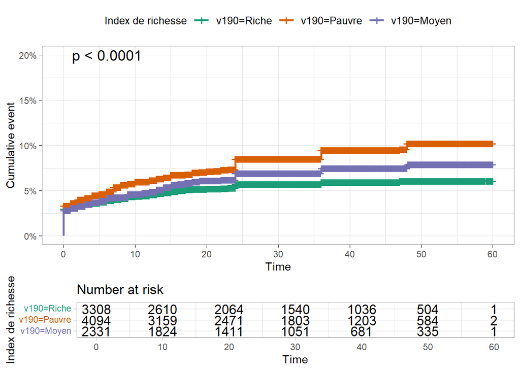

```r
courbe_richesse <- survfit( Surv(temps,deces)~v190, data = base)

ggsurvplot(courbe_richesse, fun = "event", risk.table = TRUE,surv.scale = "percent", break.time.by = 10, pval = TRUE,
           conf.int = FALSE,
           font.legend = 10,
           legend.title = "Index de richesse",
    palette = "Dark2", # spécifier la palette de couleurs
    ggtheme = theme_light()) # simplifie le fond du graphique
```

## 5 Formulation du modele de COX

```r
modele <- coxph(
  Surv(temps,deces) ~  b4 + v024 + v025 + v106 + v130 + b0 + age_mere_naissance +  rang_naissance + poids_naissance + intervalle_naissance_prec,
  data = base)
```

```r
## Visualisation des resultats

tbl_regression(modele, exponentiate = TRUE) %>%
  add_global_p() %>%
  italicize_labels() %>%
  bold_labels()
```

| **Characteristic** | **HR**<sup>1</sup> | **95% CI**<sup>1</sup> | **p-value** |
| --- | --- | --- | --- |
| Sexe |  |  | 0.017 |
| Feminin | — | — |  |
| Masculin | 1.21 | 1.03, 1.41 |  |
| Region |  |  | <0.001 |
| Centre | — | — |  |
| Adamawa | 0.74 | 0.50, 1.09 |  |
| Littoral | 0.68 | 0.48, 0.97 |  |
| Est | 1.33 | 1.01, 1.75 |  |
| Extreme Nord | 0.75 | 0.54, 1.04 |  |
| Nord | 1.01 | 0.74, 1.38 |  |
| Nord Ouest | 0.64 | 0.39, 1.05 |  |
| ouest | 0.91 | 0.65, 1.27 |  |
| Sud | 1.15 | 0.85, 1.54 |  |
| Sud ouest | 0.41 | 0.15, 1.11 |  |
| Lieu de residence |  |  | 0.9 |
| Rural | — | — |  |
| Urbain | 0.98 | 0.82, 1.19 |  |
| Niveau d'education de la mère |  |  | 0.13 |
| Pas d'education | — | — |  |
| Primaire | 1.17 | 0.92, 1.48 |  |
| Secondaire | 1.07 | 0.80, 1.43 |  |
| Superieur | 0.70 | 0.40, 1.21 |  |
| Religion |  |  | 0.005 |
| Chretien | — | — |  |
| Musulman | 1.13 | 0.92, 1.40 |  |
| Animiste | 0.37 | 0.13, 1.00 |  |
| Aucune | 0.48 | 0.22, 1.02 |  |
| L'enfant est jumeau? |  |  | <0.001 |
| Naissance unique | — | — |  |
| 1er d'une naissance multiple | 2.62 | 1.81, 3.79 |  |
| 2 eme d'une naissance multiple | 4.14 | 2.93, 5.85 |  |
| age de la mere a la naissance de l'enfant |  |  | <0.001 |
| 20-29 | — | — |  |
| < 20 | 0.71 | 0.54, 0.92 |  |
| 30-39 | 1.45 | 1.17, 1.81 |  |
| 40-49 | 4.08 | 2.87, 5.80 |  |
| Rang de l'enfant dans la flatrie |  |  | 0.3 |
| 1 | — | — |  |
| 2-3 | 1.16 | 0.56, 2.42 |  |
| 4-6 | 0.96 | 0.44, 2.09 |  |
| +7 | 0.93 | 0.41, 2.10 |  |
| Poids de l'enfant a la naissance |  |  | <0.001 |
| inferieur a 2,5 kg | — | — |  |
| 2,5-3,5 kg | 0.58 | 0.42, 0.80 |  |
| superieur a 3,5 kg | 0.49 | 0.35, 0.71 |  |
| Je ne sais pas/ pas été pésé | 1.19 | 0.86, 1.66 |  |
| Intervalle de temps par rapport a la naissance precedente |  |  | <0.001 |
| 2 ans | — | — |  |
| inferieur a 2 ans | 1.41 | 0.88, 2.27 |  |
| Premier enfant | 1.31 | 0.56, 3.07 |  |
| plus de 2 ans | 0.70 | 0.44, 1.12 |  |

<sup>1</sup> HR = Hazard Ratio, CI = Confidence Interval

## 6 Selection des variables pertinentes avec AIC

```r
 modele1 <- step(modele)
```

```
## Start:  AIC=11326.28
## Surv(temps, deces) ~ b4 + v024 + v025 + v106 + v130 + b0 + age_mere_naissance +
##     rang_naissance + poids_naissance + intervalle_naissance_prec
##
##                             Df   AIC
## - rang_naissance             3 11324
## - v025                       1 11324
## - v106                       3 11326
## <none>                         11326
## - b4                         1 11330
## - v130                       3 11333
## - v024                       9 11338
## - intervalle_naissance_prec  3 11375
## - age_mere_naissance         3 11382
## - b0                         2 11385
## - poids_naissance            3 11387
##
## Step:  AIC=11323.83
## Surv(temps, deces) ~ b4 + v024 + v025 + v106 + v130 + b0 + age_mere_naissance +
##     poids_naissance + intervalle_naissance_prec
##
##                             Df   AIC
## - v025                       1 11322
## - v106                       3 11323
## <none>                         11324
## - b4                         1 11328
## - v130                       3 11330
## - v024                       9 11334
## - intervalle_naissance_prec  3 11375
## - poids_naissance            3 11385
## - age_mere_naissance         3 11390
## - b0                         2 11392
##
## Step:  AIC=11321.83
## Surv(temps, deces) ~ b4 + v024 + v106 + v130 + b0 + age_mere_naissance +
##     poids_naissance + intervalle_naissance_prec
##
##                             Df   AIC
## - v106                       3 11321
## <none>                         11322
## - b4                         1 11326
## - v130                       3 11328
## - v024                       9 11333
## - intervalle_naissance_prec  3 11373
## - poids_naissance            3 11386
## - age_mere_naissance         3 11388
## - b0                         2 11390
##
## Step:  AIC=11320.73
## Surv(temps, deces) ~ b4 + v024 + v130 + b0 + age_mere_naissance +
##     poids_naissance + intervalle_naissance_prec
##
##                             Df   AIC
## <none>                         11321
## - b4                         1 11324
## - v130                       3 11327
## - v024                       9 11336
## - intervalle_naissance_prec  3 11370
## - age_mere_naissance         3 11386
## - b0                         2 11389
## - poids_naissance            3 11390
```

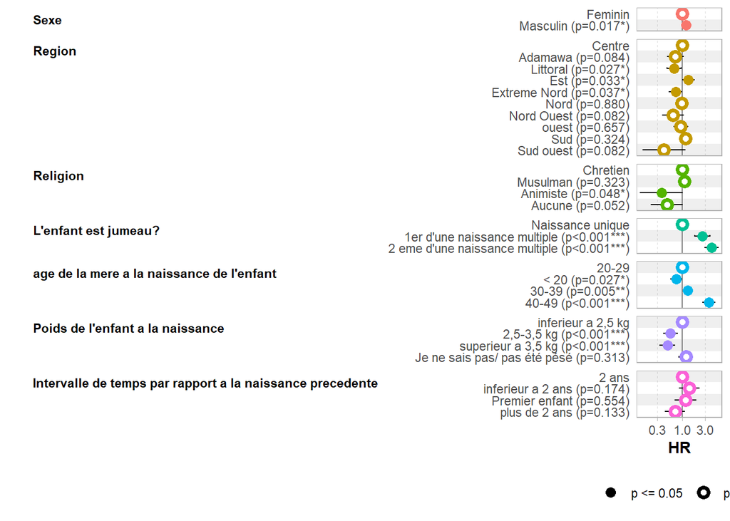

```r
##resultat du modele finale

library(GGally)
ggcoef_model(modele1, exponentiate = TRUE)
```

## 7 Interprétation des résultats

Concernant le sexe, les hommes présentent un risque 21 % plus élevé par rapport aux femmes.

Plusieurs différences notables apparaissent par rapport à la région Centre (référence). Les régions Littoral et Extrême-Nord montrent un risque réduit par rapport au Centre. À l’inverse, la région de l’Est présente un risque plus élevé. Les autres régions ne montrent pas de différence significative.

En ce qui concerne la religion, aucune différence significative n’est observée entre les chrétiens (référence) et les musulman. Toutefois, les animistes présentent un risque réduit, et ceux sans religion montrent une tendance similaire.

Le statut de jumeau est fortement associé à un risque accru. Comparé aux enfants nés d’une naissance unique, le premier jumeau présente un risque 2,6 fois plus élevé et le second jumeau, un risque encore plus marqué.

Concernant le poids de l’enfant à la naissance, par rapport aux enfants de poids inférieur à 2,5 kg, ceux pesant entre 2,5-3,5 kg et ceux de poids supérieur à 3,5 kg présentent un risque significativement réduit. En revanche, pour les enfants dont le poids n’était pas connu ou qui n’ont pas été pesés, aucune différence significative n’est observée.

Enfin, pour l’intervalle de temps par rapport à la naissance précédente, aucune différence significative n’est observée entre les différents groupes, bien que les enfants nés après moins de 2 ans montrent une légère tendance à un risque accru.